# danjtan_5

Dan Tanner

19 February, 2017

# Exercise 1

*Try to plot and calculate the correlation coefficients between the waiting time between eruptions and the duration of the eruption for the Old Faithful geyser in Yellowstone National Park. The dataset is built in R named faithful.*

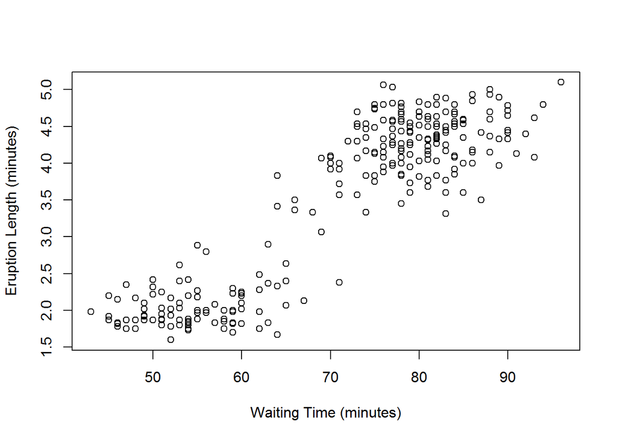

```r
data("faithful")
plot(faithful[,"eruptions"]~faithful[,"waiting"], xlab = "Waiting Time (minutes)", ylab = "Eruption Length (minutes)")
```

We can see that there is not an obvious non-linear correlation, so we procede with the test for linear correlation.

```r
cor(faithful[,"waiting"], faithful[,"eruptions"])
```

```
## [1] 0.9008112
```

With r = ~0.9 we have a strong positive linear correlation in the data, suggesting that longer waiting times and longer eruption times are associated.

# Exercise 2

## 2.1

*Build another linear model with another independent variable, Ozone, and plot it with estimated regression line.*

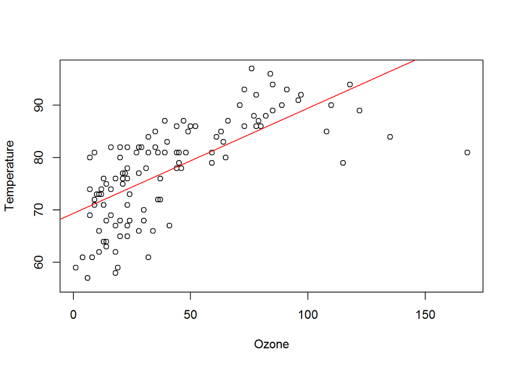

```r
mod.2.1 <- lm(Temp~Ozone, data = airquality)
plot(airquality[,"Temp"]~airquality[,"Ozone"], xlab="Ozone", ylab="Temperature")
abline(lm(Temp~Ozone, data=airquality), col="red")
```

```r
summary(mod.2.1)
```

```
##
## Call:
## lm(formula = Temp ~ Ozone, data = airquality)
##
## Residuals:
##     Min      1Q  Median      3Q     Max
## -22.147  -4.858   1.828   4.342  12.328
##
## Coefficients:
##             Estimate Std. Error t value Pr(>|t|)
## (Intercept) 69.41072    1.02971   67.41   <2e-16 ***
## Ozone        0.20081    0.01928   10.42   <2e-16 ***
## ---
## Signif. codes:  0 '***' 0.001 '**' 0.01 '*' 0.05 '.' 0.1 ' ' 1
##
## Residual standard error: 6.819 on 114 degrees of freedom
##   (37 observations deleted due to missingness)
## Multiple R-squared:  0.4877, Adjusted R-squared:  0.4832
## F-statistic: 108.5 on 1 and 114 DF,  p-value: < 2.2e-16
```

Interpretation: For each one one unit of ozone measure increase our model expects an increase in temperature of 0.2 degrees (p = 2e-16). The intercept is ~69.4, which says that at 0 ozone our model predicts a temperature of 69.4 degrees.

## 2.2

*Build a linear model to explain if you see longer eruption time if you wait for longer in the faithful dataset.*

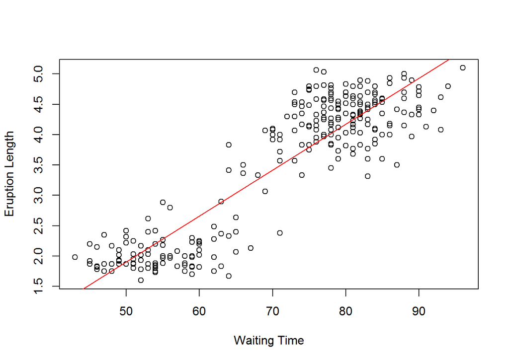

```r
mod.2.2 <- lm(eruptions~waiting, data = faithful)
plot(faithful[,"eruptions"]~faithful[,"waiting"], xlab="Waiting Time", ylab="Eruption Length")
abline(lm(eruptions~waiting, data = faithful), col="red")
```

```r
summary(mod.2.2)
```

```
##
## Call:
## lm(formula = eruptions ~ waiting, data = faithful)
##
## Residuals:
##      Min       1Q   Median       3Q      Max
## -1.29917 -0.37689  0.03508  0.34909  1.19329
##
## Coefficients:
##              Estimate Std. Error t value Pr(>|t|)
## (Intercept) -1.874016   0.160143  -11.70   <2e-16 ***
## waiting      0.075628   0.002219   34.09   <2e-16 ***
## ---
## Signif. codes:  0 '***' 0.001 '**' 0.01 '*' 0.05 '.' 0.1 ' ' 1
##
## Residual standard error: 0.4965 on 270 degrees of freedom
## Multiple R-squared:  0.8115, Adjusted R-squared:  0.8108
## F-statistic:  1162 on 1 and 270 DF,  p-value: < 2.2e-16
```

Looking at our estimates, we can see that for every additional minute we have to wait for an eruption, our model expects the eruption to last for 0.076 additional minutes (p = 2e-16). Thus we expect a longer eruption if we wait longer for it.

# Exercise 3

*Calculate the residual standard error (RSE) and mean square error (MSE) manually for the model you built last time (Ozone as the independent variable).*

```r
res = residuals(mod.2.1)
RSS = sum(res^2)
RSS
```

```
## [1] 5300.725
```

The residuals are calculated using a generic function in R funtion which extracts the residuals from a given model. To find the residual sum of squares we simply square the residual terms and sum them.

```r
MSE = RSS/summary(mod.2.1)$df[2]
MSE
```

```
## [1] 46.49759
```

The Mean Square Error is then found by dividing the RSS by the degrees of freedom of the model.